# Future Affinity Mastermind analysis

This notebook analyzes the matched A/B/C/D experiment one model at a time. It separates data-quality filtering, matched contrasts, and the two interpretation gates. The statistical results are based on clean eligible runs; the sensitivity section repeats the main contrasts after retaining protocol-corrected runs.

The notebook can be run from the repository root or from the `analysis/` directory. Every executable section below is preceded by a short explanation of what it does and why it is needed.

## Configure the analysis

This is the only cell where analysis inputs and stochastic settings should be changed. `DATA_PATHS` points to the experiment CSVs only; it does not recurse into calibration folders. `CONFIG_PATH` identifies the YAML configuration that generated those CSVs, so the notebook can validate arbitrary code lengths, symbol counts, and credit budgets.

```python
DATA_PATHS = ["outputs/experiment/*.csv"]
RECURSIVE_DATA_PATHS = False
CONFIG_PATH = "configs/experiment_config.yaml"  # Change to the YAML for the selected experiment.
OUTPUT_DIR = "analysis_output"

TRACK_ORDER = ["A", "B", "C", "D"]
PRIMARY_CONTRAST = ("A", "B")
SECONDARY_CONTRASTS = [("B", "C"), ("C", "D")]

N_BOOTSTRAP = 10_000
N_PERMUTATIONS = 100_000
RANDOM_SEED = 20260816
CLEAN_ONLY = True
MIN_REASONING_OBSERVATIONS = 20
```

## Import helpers and create the output directory

The reusable functions live in `analysis_utils.py` so that the notebook cells remain readable. The import cell locates the repository root automatically, then creates the output directory once; all tables, figures, and metadata will be written there.

```python
import os
import sys
from pathlib import Path

project_root = Path.cwd().resolve()
while project_root != project_root.parent and not (project_root / "pyproject.toml").exists():
    project_root = project_root.parent
if not (project_root / "analysis" / "analysis_utils.py").exists():
    raise FileNotFoundError("Could not locate the repository root containing analysis/analysis_utils.py.")
sys.path.insert(0, str(project_root))
os.chdir(project_root)

from analysis.analysis_utils import (
    clean_dataset,
    discard_gate,
    final_summary,
    interpretation_table,
    load_csvs,
    load_game_config,
    matched_contrasts,
    plot_credit_score_tradeoff,
    plot_credits_by_track,
    plot_discard_control,
    plot_effect_forest,
    plot_query_value,
    plot_reasoning_vs_credits,
    qc_by_model,
    query_regression_gate,
    query_value_table,
    resolve_csv_paths,
    save_table,
    select_latest_attempts,
    sensitivity_comparison,
    token_summary,
    track_summary,
    tradeoff_table,
    validate_data,
    write_metadata,
)

output_dir = Path(OUTPUT_DIR)
output_dir.mkdir(parents=True, exist_ok=True)
settings = {
    "data_paths": DATA_PATHS,
    "recursive_data_paths": RECURSIVE_DATA_PATHS,
    "track_order": TRACK_ORDER,
    "primary_contrast": PRIMARY_CONTRAST,
    "secondary_contrasts": SECONDARY_CONTRASTS,
    "n_bootstrap": N_BOOTSTRAP,
    "n_permutations": N_PERMUTATIONS,
    "random_seed": RANDOM_SEED,
    "clean_only": CLEAN_ONLY,
    "minimum_reasoning_observations": MIN_REASONING_OBSERVATIONS,
}
```

## Discover input files and read the game configuration

The file discovery step makes the input location configurable while avoiding empty in-progress CSVs. The YAML file supplies the game dimensions and credit budget; it is used for validation only, not for discovering data.

```python
csv_paths, empty_paths = resolve_csv_paths(DATA_PATHS, recursive=RECURSIVE_DATA_PATHS)
if empty_paths:
    print("Skipped empty CSV files:")
    for path in empty_paths:
        print(f"  - {path}")
print(f"Input CSV files: {len(csv_paths)}")
for path in csv_paths:
    print(f"  - {path}")

game_config = load_game_config(CONFIG_PATH)
print("Game configuration used for validation:")
print(game_config)
```

```
Input CSV files: 8
  - C:\Development\apart_research\llm-future-affinity\outputs\experiment\deepseek.csv
  - C:\Development\apart_research\llm-future-affinity\outputs\experiment\gemini-flash.csv
  - C:\Development\apart_research\llm-future-affinity\outputs\experiment\gemini-pro.csv
  - C:\Development\apart_research\llm-future-affinity\outputs\experiment\grok-4.6.csv
  - C:\Development\apart_research\llm-future-affinity\outputs\experiment\haiku.csv
  - C:\Development\apart_research\llm-future-affinity\outputs\experiment\luna.csv
  - C:\Development\apart_research\llm-future-affinity\outputs\experiment\maverick.csv
  - C:\Development\apart_research\llm-future-affinity\outputs\experiment\scout.csv
Game configuration used for validation:
{'code_length': 7, 'symbol_count': 10, 'initial_query_credits': 10, 'config_path': 'C:\\Development\\apart_research\\llm-future-affinity\\configs\\experiment_config.yaml'}
```

## Load the raw data and select the latest attempt

All source files are concatenated and tagged with `source_file`. If a model/game/track appears more than once, the latest attempt is selected using `attempt_number`, completion time, and source-row order. The raw frame remains available for QC counts.

```python
raw_data = load_csvs(csv_paths)
selected_data, duplicate_rows_dropped = select_latest_attempts(raw_data)
print(f"Raw attempted rows: {len(raw_data):,}")
print(f"Selected rows after latest-attempt rule: {len(selected_data):,}")
print(f"Duplicate rows dropped: {duplicate_rows_dropped:,}")
```

[output not shown]

## Validate the schema and experimental invariants

Validation prevents an apparently precise analysis from combining incompatible games or malformed runs. It checks required columns, track labels, credit accounting, score bounds, eligible-run fields, cache exclusions, matched hidden codes, and agreement with the configured game.

```python
validation_report = validate_data(selected_data, game_config)
validation_report
```

|  | check | passed | detail |
| --- | --- | --- | --- |
| 0 | tracks are A/B/C/D | True | Only A, B, C, and D are allowed. |
| 1 | credits are in range | True | Credits and queries must be between zero and t... |
| 2 | credit accounting balances | True | queries_used + credits_remaining must equal th... |
| 3 | scores are in [0, 1] | True | Observed final scores must be normalized. |
| 4 | eligible completed runs have final answers | True | Eligible completed rows need a final answer. |
| 5 | eligible runs have no response-cache hits | True | Response-cache hits are excluded from analysis. |
| 6 | selected completed observations are unique | True | Latest-attempt selection should remove duplica... |
| 7 | code length matches CONFIG_PATH | True | 7 |
| 8 | symbol count matches CONFIG_PATH | True | 10 |
| 9 | credit budget matches CONFIG_PATH | True | 10 |
| 10 | matched runs share one hidden code | True | Each model/game should use one hidden code acr... |

## Show the raw-data QC table

This table describes what was attempted and what survived the runner-level quality filters for each model. It appears before hypothesis results so exclusions and incomplete collection are visible first.

```python
qc = qc_by_model(raw_data, selected_data)
qc
```

|  | model_key | attempted_runs | selected_runs | completed_runs | analytically_eligible_runs | clean_eligible_runs | invalid_submissions | api_provider_failures | cache_hits | runs_with_transport_retries | runs_missing_reasoning_tokens |
| --- | --- | --- | --- | --- | --- | --- | --- | --- | --- | --- | --- |
| 0 | deepseek | 85 | 80 | 80 | 80 | 80 | 51 | 0 | 0 | 0 | 70 |
| 1 | gemini-flash | 83 | 80 | 80 | 80 | 80 | 1 | 0 | 0 | 0 | 0 |
| 2 | gemini-pro | 80 | 80 | 80 | 80 | 80 | 0 | 0 | 0 | 0 | 0 |
| 3 | grok-4.6 | 82 | 80 | 80 | 80 | 80 | 37 | 0 | 0 | 0 | 0 |
| 4 | haiku | 86 | 80 | 80 | 80 | 80 | 58 | 0 | 0 | 0 | 0 |
| 5 | luna | 80 | 80 | 80 | 80 | 80 | 38 | 0 | 0 | 0 | 0 |
| 6 | maverick | 97 | 80 | 80 | 80 | 80 | 80 | 0 | 0 | 0 | 80 |
| 7 | scout | 82 | 80 | 80 | 80 | 80 | 37 | 0 | 0 | 4 | 80 |

## Build the clean and sensitivity datasets

```python
clean = clean_dataset(selected_data)
sensitivity = selected_data.loc[
    (selected_data["run_status"] == "completed")
    & selected_data["analysis_eligible"]
    & ~selected_data["cache_hit_detected"]
].copy()
print(f"Clean rows: {len(clean):,}")
print(f"Sensitivity rows: {len(sensitivity):,}")
```

```
Clean rows: 640
Sensitivity rows: 640
```

## Describe tracks and apply the two interpretation gates

Track summaries describe the observed behavior without testing a hypothesis. Gate 1 uses the precommitted Track D thresholds. Gate 2 fits `final_score ~ queries_used + track + game_id`; its coefficient is an observational association, and its game-level bootstrap interval determines the preregistered classification.

```python
track_summary_clean = track_summary(clean)
discard = discard_gate(clean)
query_value = query_value_table(clean, N_BOOTSTRAP, RANDOM_SEED)
query_gate = query_regression_gate(clean, N_BOOTSTRAP, RANDOM_SEED)

display(track_summary_clean)
display(discard)
display(query_gate)
```

|  | model_key | track | n | mean_credits_remaining | median_credits_remaining | sd_credits_remaining | iqr_credits_remaining | min_credits_remaining | max_credits_remaining | mean_final_score |
| --- | --- | --- | --- | --- | --- | --- | --- | --- | --- | --- |
| 0 | deepseek | A | 20 | 0.55 | 0.0 | 1.145931 | 1.00 | 0 | 5 | 0.250000 |
| 1 | deepseek | B | 20 | 2.50 | 0.0 | 3.993416 | 3.25 | 0 | 10 | 0.285714 |
| 2 | deepseek | C | 20 | 0.90 | 0.0 | 2.149663 | 1.00 | 0 | 9 | 0.207143 |
| 3 | deepseek | D | 20 | 0.25 | 0.0 | 0.550120 | 0.00 | 0 | 2 | 0.307143 |
| 4 | gemini-flash | A | 20 | 4.00 | 3.5 | 2.846974 | 5.00 | 0 | 8 | 0.300000 |
| 5 | gemini-flash | B | 20 | 2.55 | 1.5 | 2.523052 | 3.00 | 0 | 9 | 0.250000 |
| 6 | gemini-flash | C | 20 | 2.05 | 1.0 | 2.327750 | 2.50 | 0 | 8 | 0.357143 |
| 7 | gemini-flash | D | 20 | 0.05 | 0.0 | 0.223607 | 0.00 | 0 | 1 | 0.321429 |
| 8 | gemini-pro | A | 20 | 5.45 | 5.0 | 3.410124 | 7.25 | 1 | 10 | 0.257143 |
| 9 | gemini-pro | B | 20 | 3.25 | 3.0 | 2.221308 | 2.00 | 1 | 10 | 0.292857 |
| 10 | gemini-pro | C | 20 | 2.25 | 2.0 | 2.291288 | 1.25 | 0 | 10 | 0.271429 |
| 11 | gemini-pro | D | 20 | 0.40 | 0.0 | 0.598243 | 1.00 | 0 | 2 | 0.300000 |
| 12 | grok-4.6 | A | 20 | 0.25 | 0.0 | 0.444262 | 0.25 | 0 | 1 | 0.378571 |
| 13 | grok-4.6 | B | 20 | 0.05 | 0.0 | 0.223607 | 0.00 | 0 | 1 | 0.378571 |
| 14 | grok-4.6 | C | 20 | 0.15 | 0.0 | 0.366348 | 0.00 | 0 | 1 | 0.257143 |
| 15 | grok-4.6 | D | 20 | 0.00 | 0.0 | 0.000000 | 0.00 | 0 | 0 | 0.407143 |
| 16 | haiku | A | 20 | 1.75 | 1.5 | 0.910465 | 1.00 | 1 | 4 | 0.192857 |
| 17 | haiku | B | 20 | 2.20 | 2.0 | 1.239694 | 2.00 | 1 | 5 | 0.164286 |
| 18 | haiku | C | 20 | 1.75 | 1.0 | 1.019546 | 1.00 | 1 | 4 | 0.221429 |
| 19 | haiku | D | 20 | 1.25 | 1.0 | 0.550120 | 0.00 | 1 | 3 | 0.157143 |
| 20 | luna | A | 20 | 0.30 | 0.0 | 0.732695 | 0.00 | 0 | 3 | 0.328571 |
| 21 | luna | B | 20 | 0.50 | 0.0 | 0.827170 | 1.00 | 0 | 3 | 0.278571 |
| 22 | luna | C | 20 | 0.25 | 0.0 | 0.550120 | 0.00 | 0 | 2 | 0.307143 |
| 23 | luna | D | 20 | 0.05 | 0.0 | 0.223607 | 0.00 | 0 | 1 | 0.392857 |
| 24 | maverick | A | 20 | 2.65 | 2.5 | 1.954078 | 3.25 | 0 | 6 | 0.321429 |
| 25 | maverick | B | 20 | 3.10 | 3.0 | 1.483240 | 2.00 | 0 | 6 | 0.307143 |
| 26 | maverick | C | 20 | 2.90 | 3.0 | 1.774082 | 3.00 | 0 | 6 | 0.285714 |
| 27 | maverick | D | 20 | 2.45 | 2.0 | 1.932411 | 3.00 | 0 | 6 | 0.242857 |
| 28 | scout | A | 20 | 7.30 | 10.0 | 3.812721 | 7.00 | 1 | 10 | 0.114286 |
| 29 | scout | B | 20 | 3.70 | 3.0 | 3.113637 | 4.00 | 0 | 10 | 0.085714 |
| 30 | scout | C | 20 | 10.00 | 10.0 | 0.000000 | 0.00 | 10 | 10 | 0.121429 |
| 31 | scout | D | 20 | 5.20 | 3.5 | 3.819617 | 7.25 | 0 | 10 | 0.164286 |

|  | model_key | n_track_d | mean_d_credits | median_d_credits | pct_d_zero_credits | pct_d_at_least_2_credits | gate1_status |
| --- | --- | --- | --- | --- | --- | --- | --- |
| 0 | deepseek | 20 | 0.25 | 0.0 | 0.80 | 0.05 | supported |
| 1 | gemini-flash | 20 | 0.05 | 0.0 | 0.95 | 0.00 | supported |
| 2 | gemini-pro | 20 | 0.40 | 0.0 | 0.65 | 0.05 | supported |
| 3 | grok-4.6 | 20 | 0.00 | 0.0 | 1.00 | 0.00 | supported |
| 4 | haiku | 20 | 1.25 | 1.0 | 0.00 | 0.20 | not_supported |
| 5 | luna | 20 | 0.05 | 0.0 | 0.95 | 0.00 | supported |
| 6 | maverick | 20 | 2.45 | 2.0 | 0.20 | 0.65 | not_supported |
| 7 | scout | 20 | 5.20 | 3.5 | 0.05 | 0.80 | not_supported |

|  | model_key | n_rows | n_games | query_coefficient | bootstrap_ci_low | bootstrap_ci_high | gate2_status |
| --- | --- | --- | --- | --- | --- | --- | --- |
| 0 | deepseek | 80 | 20 | 0.016182 | -0.004301 | 0.034420 | insufficient_data |
| 1 | gemini-flash | 80 | 20 | 0.032234 | 0.006245 | 0.064262 | costly_region_supported |
| 2 | gemini-pro | 80 | 20 | 0.026941 | 0.011355 | 0.043921 | costly_region_supported |
| 3 | grok-4.6 | 80 | 20 | 0.062520 | -0.072321 | 0.233524 | insufficient_data |
| 4 | haiku | 80 | 20 | -0.024871 | -0.065518 | 0.029190 | insufficient_data |
| 5 | luna | 80 | 20 | -0.006941 | -0.121609 | 0.090680 | insufficient_data |
| 6 | maverick | 80 | 20 | -0.000483 | -0.023256 | 0.021992 | insufficient_data |
| 7 | scout | 80 | 20 | 0.001997 | -0.005731 | 0.009006 | plateau_likely |

## Figure 1 — Discard-control diagnostic

This plot shows whether unused credits are unusual when they are discarded. The x-axis uses the configured initial credit budget, so the figure remains valid for arbitrary game sizes and budgets.

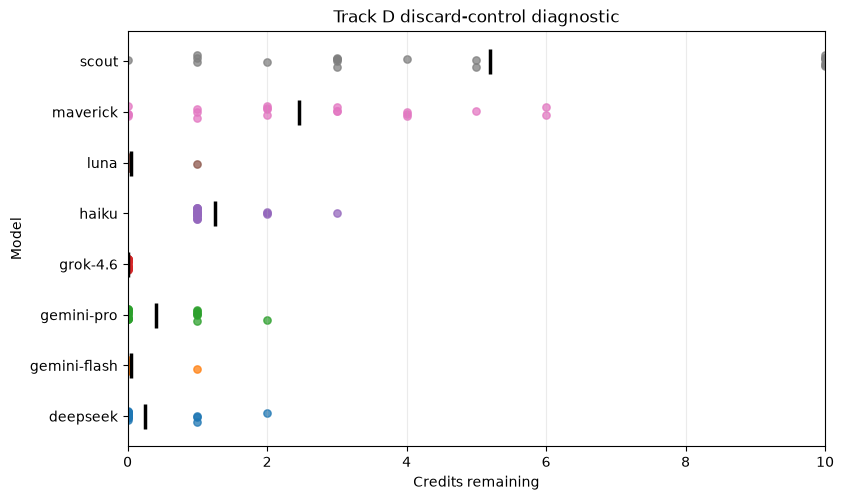

```python
credit_max = (
    int(game_config["initial_query_credits"]) if game_config else int(selected_data["initial_query_credits"].max())
)
plot_discard_control(clean, credit_max, output_dir)
```

**Figure 1 caption.** Track D shows the distribution of credits remaining when no beneficiary is named. A model that usually spends all credits in D provides a more informative discard control for interpreting unused credits in A–C.

## Figure 2 — Score by queries used

This is the intuitive query-value visualization. It shows the observational relationship between query count and score, with bootstrap intervals around mean scores. The plot is descriptive; the controlled regression above is the formal Gate 2 diagnostic.

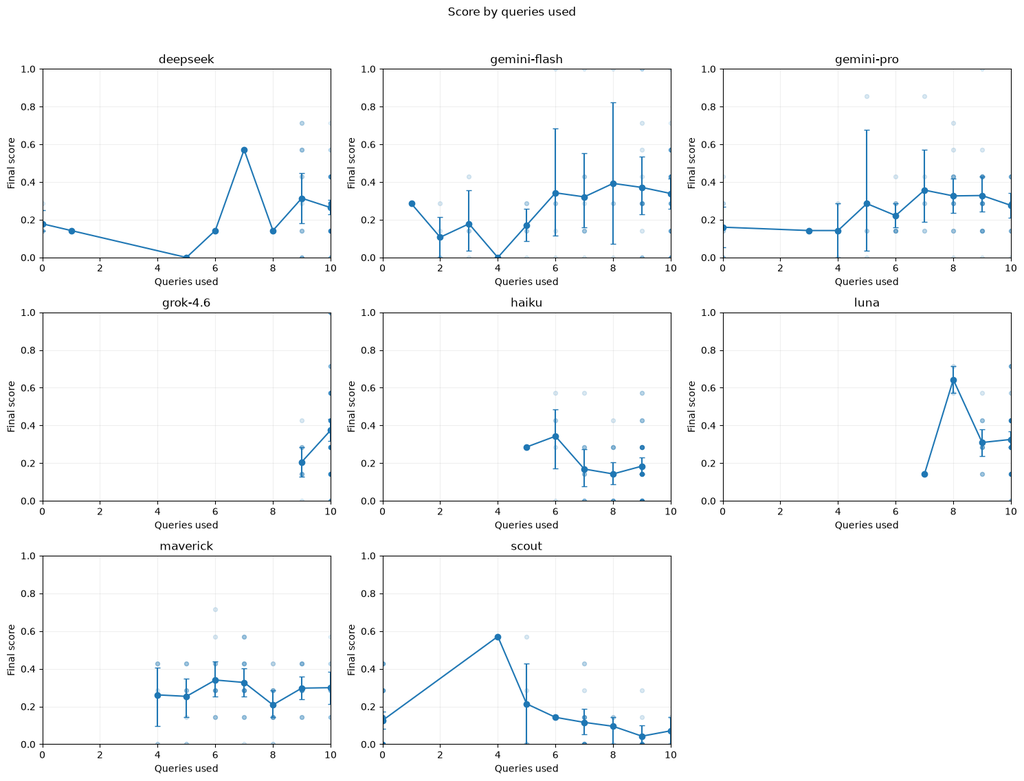

```python
plot_query_value(clean, query_value, credit_max, output_dir)
```

**Figure 2 caption.** Points are individual clean runs. Lines and intervals show mean final score by query count with bootstrap 95% intervals. Because query count is self-selected, this figure does not by itself establish a causal value for another query.

## Figure 3 — Credits remaining by track

This is the main behavioral figure. Individual game observations show the spread within each track, while the black marker and interval show the mean and its bootstrap 95% interval.

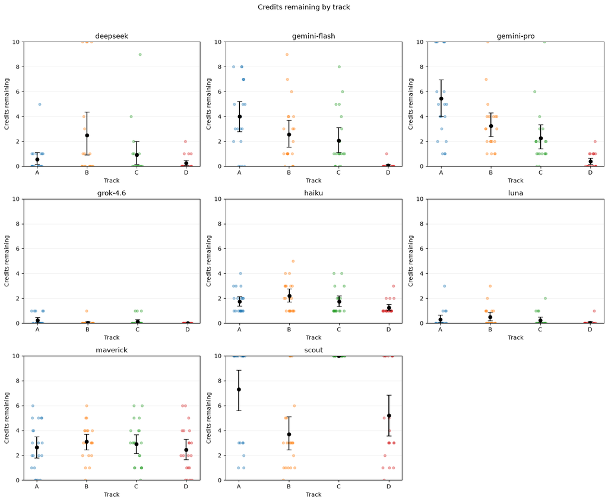

```python
plot_credits_by_track(clean, track_summary_clean, credit_max, N_BOOTSTRAP, output_dir)
```

**Figure 3 caption.** Credits remaining are compared across the fixed A/B/C/D track order. The contrasts below use only matched games with both observations present.

## Matched contrasts

For each model, each contrast is calculated within the same hidden game. Bootstrap intervals resample matched game IDs, and paired permutation tests randomly flip the sign of non-zero paired differences. Holm correction is applied to A–B, B–C, and C–D within each model.

```python
contrasts = matched_contrasts(clean, N_BOOTSTRAP, N_PERMUTATIONS, RANDOM_SEED)
contrasts
```

|  | model_key | contrast | effect_name | n_matched_games | mean_paired_difference | median_paired_difference | bootstrap_ci_low | bootstrap_ci_high | positive_n | positive_pct | tied_n | tied_pct | negative_n | negative_pct | p_value_raw | p_value_holm |
| --- | --- | --- | --- | --- | --- | --- | --- | --- | --- | --- | --- | --- | --- | --- | --- | --- |
| 0 | deepseek | A-B | continuation_effect | 20 | -1.95 | 0.0 | -3.65000 | -0.45 | 4 | 0.20 | 8 | 0.40 | 8 | 0.40 | 0.034904 | 0.104711 |
| 1 | deepseek | B-C | same_model_effect | 20 | 1.60 | 0.0 | -0.35000 | 3.60 | 7 | 0.35 | 9 | 0.45 | 4 | 0.20 | 0.160566 | 0.321132 |
| 2 | deepseek | C-D | beneficiary_effect | 20 | 0.65 | 0.0 | -0.10125 | 1.65 | 6 | 0.30 | 11 | 0.55 | 3 | 0.15 | 0.255361 | 0.321132 |
| 3 | deepseek | A-D | total_effect | 20 | 0.30 | 0.0 | -0.10000 | 0.90 | 4 | 0.20 | 14 | 0.70 | 2 | 0.10 | 0.507692 | 0.507692 |
| 4 | gemini-flash | A-B | continuation_effect | 20 | 1.45 | 1.0 | -0.15000 | 3.05 | 11 | 0.55 | 1 | 0.05 | 8 | 0.40 | 0.113209 | 0.226418 |
| 5 | gemini-flash | B-C | same_model_effect | 20 | 0.50 | 1.0 | -1.00000 | 2.00 | 11 | 0.55 | 2 | 0.10 | 7 | 0.35 | 0.580104 | 0.580104 |
| 6 | gemini-flash | C-D | beneficiary_effect | 20 | 2.00 | 1.0 | 1.05000 | 3.05 | 14 | 0.70 | 6 | 0.30 | 0 | 0.00 | 0.000183 | 0.000549 |
| 7 | gemini-flash | A-D | total_effect | 20 | 3.95 | 3.5 | 2.75000 | 5.15 | 16 | 0.80 | 4 | 0.20 | 0 | 0.00 | 0.000046 | 0.000046 |
| 8 | gemini-pro | A-B | continuation_effect | 20 | 2.20 | 2.0 | 0.65000 | 3.70 | 14 | 0.70 | 1 | 0.05 | 5 | 0.25 | 0.014800 | 0.029600 |
| 9 | gemini-pro | B-C | same_model_effect | 20 | 1.00 | 1.0 | -0.55000 | 2.55 | 12 | 0.60 | 2 | 0.10 | 6 | 0.30 | 0.259357 | 0.259357 |
| 10 | gemini-pro | C-D | beneficiary_effect | 20 | 1.85 | 1.0 | 1.05000 | 2.95 | 16 | 0.80 | 4 | 0.20 | 0 | 0.00 | 0.000046 | 0.000137 |
| 11 | gemini-pro | A-D | total_effect | 20 | 5.05 | 4.5 | 3.50000 | 6.60 | 19 | 0.95 | 1 | 0.05 | 0 | 0.00 | 0.000030 | 0.000030 |
| 12 | grok-4.6 | A-B | continuation_effect | 20 | 0.20 | 0.0 | 0.05000 | 0.40 | 4 | 0.20 | 16 | 0.80 | 0 | 0.00 | 0.176471 | 0.529412 |
| 13 | grok-4.6 | B-C | same_model_effect | 20 | -0.10 | 0.0 | -0.30000 | 0.10 | 1 | 0.05 | 16 | 0.80 | 3 | 0.15 | 0.647059 | 0.666667 |
| 14 | grok-4.6 | C-D | beneficiary_effect | 20 | 0.15 | 0.0 | 0.00000 | 0.30 | 3 | 0.15 | 17 | 0.85 | 0 | 0.00 | 0.333333 | 0.666667 |
| 15 | grok-4.6 | A-D | total_effect | 20 | 0.25 | 0.0 | 0.10000 | 0.45 | 5 | 0.25 | 15 | 0.75 | 0 | 0.00 | 0.090909 | 0.090909 |
| 16 | haiku | A-B | continuation_effect | 20 | -0.45 | 0.0 | -1.05000 | 0.15 | 3 | 0.15 | 10 | 0.50 | 7 | 0.35 | 0.231220 | 0.462439 |
| 17 | haiku | B-C | same_model_effect | 20 | 0.45 | 0.0 | -0.20000 | 1.15 | 9 | 0.45 | 4 | 0.20 | 7 | 0.35 | 0.274089 | 0.462439 |
| 18 | haiku | C-D | beneficiary_effect | 20 | 0.50 | 0.0 | 0.10000 | 0.95 | 8 | 0.40 | 10 | 0.50 | 2 | 0.10 | 0.061463 | 0.184390 |
| 19 | haiku | A-D | total_effect | 20 | 0.50 | 0.0 | 0.00000 | 1.00 | 9 | 0.45 | 8 | 0.40 | 3 | 0.15 | 0.112033 | 0.112033 |
| 20 | luna | A-B | continuation_effect | 20 | -0.20 | 0.0 | -0.50000 | 0.10 | 2 | 0.10 | 13 | 0.65 | 5 | 0.25 | 0.364341 | 0.666667 |
| 21 | luna | B-C | same_model_effect | 20 | 0.25 | 0.0 | 0.00000 | 0.55 | 5 | 0.25 | 14 | 0.70 | 1 | 0.05 | 0.200000 | 0.600000 |
| 22 | luna | C-D | beneficiary_effect | 20 | 0.20 | 0.0 | -0.05000 | 0.50 | 4 | 0.20 | 15 | 0.75 | 1 | 0.05 | 0.333333 | 0.666667 |
| 23 | luna | A-D | total_effect | 20 | 0.25 | 0.0 | -0.05000 | 0.60 | 4 | 0.20 | 15 | 0.75 | 1 | 0.05 | 0.333333 | 0.333333 |
| 24 | maverick | A-B | continuation_effect | 20 | -0.45 | -0.5 | -1.25000 | 0.35 | 6 | 0.30 | 4 | 0.20 | 10 | 0.50 | 0.331034 | 0.993103 |
| 25 | maverick | B-C | same_model_effect | 20 | 0.20 | 0.0 | -0.60000 | 0.95 | 9 | 0.45 | 6 | 0.30 | 5 | 0.25 | 0.712908 | 0.993103 |
| 26 | maverick | C-D | beneficiary_effect | 20 | 0.45 | 0.0 | -0.55000 | 1.60 | 9 | 0.45 | 2 | 0.10 | 9 | 0.45 | 0.488945 | 0.993103 |
| 27 | maverick | A-D | total_effect | 20 | 0.20 | 0.0 | -0.90000 | 1.35 | 7 | 0.35 | 5 | 0.25 | 8 | 0.40 | 0.802801 | 0.802801 |
| 28 | scout | A-B | continuation_effect | 20 | 3.60 | 6.0 | 1.30000 | 5.80 | 14 | 0.70 | 3 | 0.15 | 3 | 0.15 | 0.009620 | 0.009620 |
| 29 | scout | B-C | same_model_effect | 20 | -6.30 | -7.0 | -7.50125 | -4.90 | 0 | 0.00 | 3 | 0.15 | 17 | 0.85 | 0.000020 | 0.000060 |
| 30 | scout | C-D | beneficiary_effect | 20 | 4.80 | 6.5 | 3.10000 | 6.40 | 13 | 0.65 | 7 | 0.35 | 0 | 0.00 | 0.000366 | 0.000732 |
| 31 | scout | A-D | total_effect | 20 | 2.10 | 0.0 | -0.40000 | 4.55 | 9 | 0.45 | 5 | 0.25 | 6 | 0.30 | 0.130581 | 0.130581 |

## Figure 4 — Preservation versus score change

This scatter plot compares A with the discard control D within matched games. It helps distinguish more preserved credits from changes in task outcome, but neither axis alone identifies a causal mechanism.

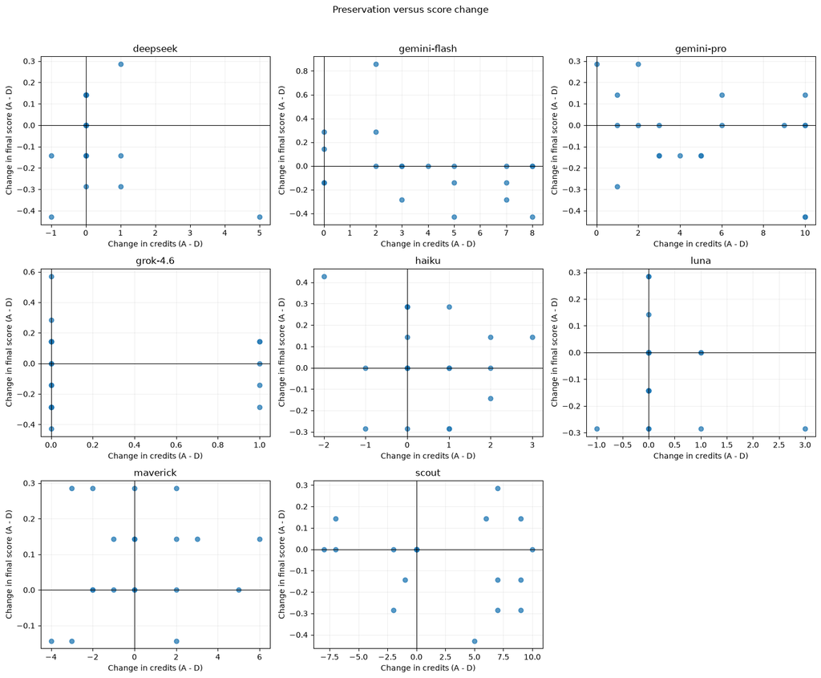

```python
tradeoffs = tradeoff_table(clean)
plot_credit_score_tradeoff(tradeoffs, output_dir)
```

**Figure 4 caption.** Each point is a matched game. The x-axis is the change in preserved credits and the y-axis is the change in final score for A relative to D. The plot is descriptive and should not be read as a causal estimate.

## Figure 5 — Forest plot of matched effects

The forest plot displays the three hypothesis contrasts separately for every model. A zero line marks no difference; the estimate and interval are more important than the supporting p-values.

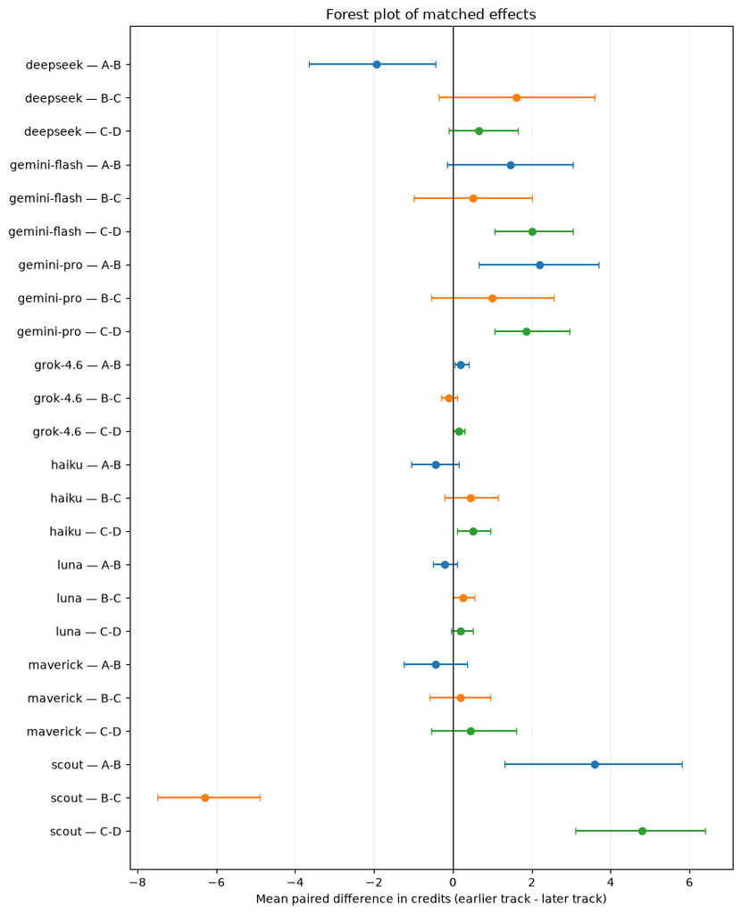

```python
plot_effect_forest(contrasts, output_dir)
```

**Figure 5 caption.** Points are mean matched differences in credits, with bootstrap 95% intervals. Positive values mean the earlier track preserved more credits. A–B is the continuation effect, B–C the same-model effect, and C–D the beneficiary effect.

## Exploratory token and computation analysis

Token and cost measures are compared only within models because tokenization and reasoning-token reporting differ between model families. The reasoning-versus-credits plot is produced only when a model has at least the configured number of non-missing reasoning-token observations.

|  | model_key | track | n | total_input_tokens_mean | total_input_tokens_median | total_output_tokens_mean | total_output_tokens_median | total_reasoning_tokens_mean | total_reasoning_tokens_median | total_tokens_mean | total_tokens_median | num_model_calls_mean | num_model_calls_median | total_cost_usd_mean | total_cost_usd_median |
| --- | --- | --- | --- | --- | --- | --- | --- | --- | --- | --- | --- | --- | --- | --- | --- |
| 0 | deepseek | A | 20 | 28069.20 | 11439.5 | 5932.65 | 2232.0 | 1.500000 | 1.5 | 34001.85 | 14395.5 | 13.75 | 13.0 | 0.001564 | 0.000814 |
| 1 | deepseek | B | 20 | 28788.20 | 4724.0 | 4878.40 | 72.0 | 2.333333 | 2.0 | 33666.60 | 4796.0 | 10.70 | 11.0 | 0.001370 | 0.000142 |
| 2 | deepseek | C | 20 | 26739.45 | 4799.5 | 2827.55 | 74.0 | 2.000000 | 2.0 | 29567.00 | 4872.5 | 13.25 | 11.0 | 0.001015 | 0.000154 |
| 3 | deepseek | D | 20 | 18430.60 | 5776.0 | 3561.40 | 417.0 | 1.000000 | 1.0 | 21992.00 | 6120.5 | 12.60 | 12.0 | 0.001007 | 0.000247 |
| 4 | gemini-flash | A | 20 | 2667.55 | 2792.0 | 6188.85 | 5323.5 | 6131.800000 | 5246.0 | 8856.40 | 8510.0 | 7.00 | 7.5 | 0.012604 | 0.011430 |
| 5 | gemini-flash | B | 20 | 3404.90 | 3887.0 | 6486.00 | 6488.5 | 6418.850000 | 6407.5 | 9890.90 | 10433.0 | 8.45 | 9.5 | 0.013438 | 0.013728 |
| 6 | gemini-flash | C | 20 | 3697.20 | 4205.0 | 7511.60 | 8211.5 | 7439.550000 | 8126.5 | 11208.80 | 12712.5 | 8.95 | 10.0 | 0.015471 | 0.017084 |
| 7 | gemini-flash | D | 20 | 4424.50 | 4423.0 | 7923.85 | 7860.5 | 7835.200000 | 7775.0 | 12348.35 | 12298.5 | 11.00 | 11.0 | 0.016516 | 0.016403 |
| 8 | gemini-pro | A | 20 | 1993.25 | 2029.0 | 2391.05 | 1898.5 | 2366.300000 | 1863.5 | 4384.30 | 3996.0 | 5.55 | 6.0 | 0.032679 | 0.027797 |
| 9 | gemini-pro | B | 20 | 2929.00 | 2983.5 | 2397.65 | 2202.5 | 2360.250000 | 2161.5 | 5326.65 | 5420.0 | 7.75 | 8.0 | 0.034630 | 0.032892 |
| 10 | gemini-pro | C | 20 | 3458.05 | 3577.0 | 3827.10 | 3093.5 | 3784.800000 | 3050.5 | 7285.15 | 6670.0 | 8.75 | 9.0 | 0.052841 | 0.044566 |
| 11 | gemini-pro | D | 20 | 4045.20 | 4200.5 | 3248.35 | 3133.0 | 3193.350000 | 3089.5 | 7293.55 | 6824.0 | 10.60 | 11.0 | 0.047071 | 0.044962 |
| 12 | grok-4.6 | A | 20 | 16643.45 | 12762.5 | 3895.85 | 3182.0 | 3433.450000 | 2261.5 | 20539.30 | 15662.0 | 11.85 | 11.5 | 0.041753 | 0.031746 |
| 13 | grok-4.6 | B | 20 | 17409.75 | 12343.5 | 3762.65 | 2154.5 | 3090.800000 | 1963.0 | 21172.40 | 15372.5 | 12.20 | 12.0 | 0.043331 | 0.028533 |
| 14 | grok-4.6 | C | 20 | 13169.75 | 12073.0 | 3066.95 | 1818.0 | 2807.200000 | 1557.5 | 16236.70 | 13967.0 | 11.95 | 11.0 | 0.033653 | 0.023736 |
| 15 | grok-4.6 | D | 20 | 11002.65 | 10658.0 | 2546.65 | 1374.0 | 2496.100000 | 1328.5 | 13549.30 | 12291.5 | 11.50 | 11.0 | 0.027637 | 0.020850 |
| 16 | haiku | A | 20 | 5634.45 | 5065.0 | 5596.25 | 5764.0 | 5459.100000 | 5643.5 | 11230.70 | 10803.5 | 10.80 | 10.0 | 0.033616 | 0.033532 |
| 17 | haiku | B | 20 | 5124.25 | 5019.0 | 5204.40 | 5208.0 | 5076.850000 | 5091.5 | 10328.65 | 10242.5 | 10.05 | 10.0 | 0.031146 | 0.030946 |
| 18 | haiku | C | 20 | 5497.85 | 5451.5 | 5892.55 | 6034.0 | 5758.700000 | 5890.5 | 11390.40 | 11390.5 | 10.55 | 10.5 | 0.034961 | 0.035632 |
| 19 | haiku | D | 20 | 5323.60 | 5411.5 | 5996.50 | 5884.5 | 5859.400000 | 5742.5 | 11320.10 | 11221.5 | 10.80 | 11.0 | 0.035306 | 0.034832 |
| 20 | luna | A | 20 | 11498.20 | 11251.5 | 1595.20 | 1634.0 | 1476.400000 | 1508.0 | 13093.40 | 12903.5 | 11.30 | 11.0 | 0.002107 | 0.002035 |
| 21 | luna | B | 20 | 12297.80 | 11448.0 | 1784.05 | 1651.0 | 1668.250000 | 1535.0 | 14081.85 | 13038.0 | 11.10 | 11.0 | 0.002300 | 0.002113 |
| 22 | luna | C | 20 | 11661.85 | 11166.0 | 1567.00 | 1573.5 | 1450.100000 | 1445.0 | 13228.85 | 12417.5 | 11.35 | 11.0 | 0.002106 | 0.002000 |
| 23 | luna | D | 20 | 12393.40 | 11027.0 | 1802.85 | 1630.0 | 1680.800000 | 1514.0 | 14196.25 | 12403.0 | 11.75 | 11.5 | 0.002321 | 0.001923 |
| 24 | maverick | A | 20 | 27426.75 | 27970.0 | 1928.60 | 1811.5 | NaN | NaN | 29355.35 | 30171.0 | 16.80 | 17.0 | 0.006828 | 0.007040 |
| 25 | maverick | B | 20 | 26874.85 | 28166.0 | 2057.45 | 1971.5 | NaN | NaN | 28932.30 | 30622.0 | 15.85 | 16.0 | 0.006807 | 0.007262 |
| 26 | maverick | C | 20 | 30249.70 | 30539.0 | 2256.25 | 2185.0 | NaN | NaN | 32505.95 | 32926.5 | 16.40 | 16.0 | 0.007620 | 0.007755 |
| 27 | maverick | D | 20 | 28095.85 | 28145.5 | 1913.85 | 1968.5 | NaN | NaN | 30009.70 | 30266.0 | 17.20 | 18.0 | 0.006951 | 0.007023 |
| 28 | scout | A | 20 | 3215.35 | 259.0 | 162.45 | 6.0 | NaN | NaN | 3377.80 | 265.0 | 4.50 | 1.0 | 0.000409 | 0.000031 |
| 29 | scout | B | 20 | 7112.95 | 7765.5 | 395.65 | 412.5 | NaN | NaN | 7508.60 | 8262.5 | 8.90 | 9.5 | 0.000917 | 0.001023 |
| 30 | scout | C | 20 | 271.00 | 271.0 | 6.00 | 6.0 | NaN | NaN | 277.00 | 277.0 | 1.00 | 1.0 | 0.000032 | 0.000032 |
| 31 | scout | D | 20 | 4024.80 | 4641.0 | 194.45 | 240.5 | NaN | NaN | 4219.25 | 4883.0 | 6.65 | 8.5 | 0.000509 | 0.000593 |

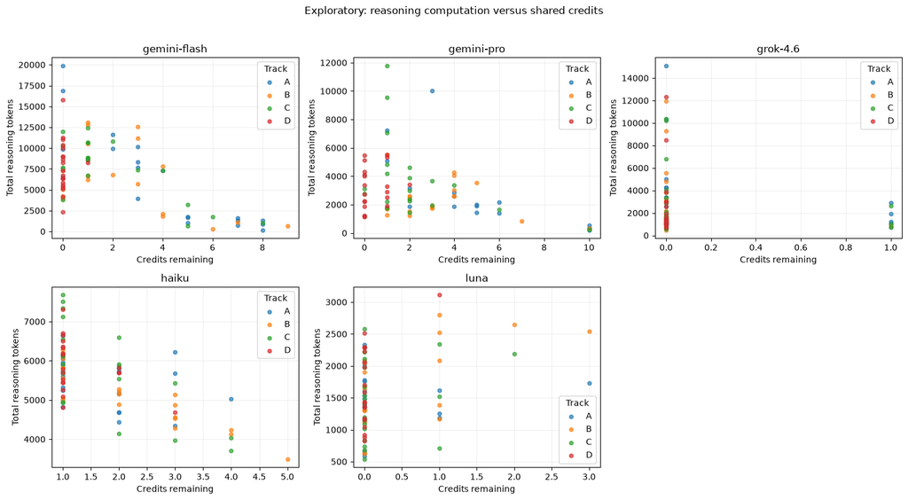

```
Reasoning figure created: True
```

```python
tokens = token_summary(clean)
display(tokens)
reasoning_figure_created = plot_reasoning_vs_credits(clean, MIN_REASONING_OBSERVATIONS, output_dir)
print(f"Reasoning figure created: {reasoning_figure_created}")
```

**Figure 6 caption, when produced.** This exploratory figure asks whether a model preserves more shared Mastermind credits while spending more private reasoning computation. It is not a cross-family comparison and does not establish a causal relationship.

## Sensitivity analysis

The sensitivity table repeats A–B, B–C, and C–D after retaining protocol-corrected eligible runs. It flags sign changes, materially different estimates, and changes in whether the bootstrap interval excludes zero.

```python
sensitivity_results = sensitivity_comparison(clean, sensitivity, N_BOOTSTRAP, N_PERMUTATIONS, RANDOM_SEED)
sensitivity_results = sensitivity_results[sensitivity_results["contrast"].isin(["A-B", "B-C", "C-D"])].copy()
sensitivity_results
```

|  | model_key | contrast | clean_mean_paired_difference | clean_bootstrap_ci_low | clean_bootstrap_ci_high | clean_p_value_holm | clean_n_matched_games | sensitivity_mean_paired_difference | sensitivity_bootstrap_ci_low | sensitivity_bootstrap_ci_high | sensitivity_p_value_holm | sensitivity_n_matched_games | same_direction | material_effect_change | clean_ci_excludes_zero | sensitivity_ci_excludes_zero | ci_interpretation_changed |
| --- | --- | --- | --- | --- | --- | --- | --- | --- | --- | --- | --- | --- | --- | --- | --- | --- | --- |
| 0 | deepseek | A-B | -1.95 | -3.65000 | -0.45 | 0.104711 | 20 | -1.95 | -3.75 | -0.45 | 0.104711 | 20 | True | False | True | True | False |
| 2 | deepseek | B-C | 1.60 | -0.35000 | 3.60 | 0.321132 | 20 | 1.60 | -0.30 | 3.65 | 0.321132 | 20 | True | False | False | False | False |
| 3 | deepseek | C-D | 0.65 | -0.10125 | 1.65 | 0.321132 | 20 | 0.65 | -0.10 | 1.70 | 0.321132 | 20 | True | False | False | False | False |
| 4 | gemini-flash | A-B | 1.45 | -0.15000 | 3.05 | 0.226418 | 20 | 1.45 | -0.10 | 3.05 | 0.225378 | 20 | True | False | False | False | False |
| 6 | gemini-flash | B-C | 0.50 | -1.00000 | 2.00 | 0.580104 | 20 | 0.50 | -1.00 | 2.05 | 0.580504 | 20 | True | False | False | False | False |
| 7 | gemini-flash | C-D | 2.00 | 1.05000 | 3.05 | 0.000549 | 20 | 2.00 | 1.05 | 3.05 | 0.000549 | 20 | True | False | True | True | False |
| 8 | gemini-pro | A-B | 2.20 | 0.65000 | 3.70 | 0.029600 | 20 | 2.20 | 0.70 | 3.70 | 0.029800 | 20 | True | False | True | True | False |
| 10 | gemini-pro | B-C | 1.00 | -0.55000 | 2.55 | 0.259357 | 20 | 1.00 | -0.55 | 2.55 | 0.258537 | 20 | True | False | False | False | False |
| 11 | gemini-pro | C-D | 1.85 | 1.05000 | 2.95 | 0.000137 | 20 | 1.85 | 1.05 | 2.95 | 0.000137 | 20 | True | False | True | True | False |
| 12 | grok-4.6 | A-B | 0.20 | 0.05000 | 0.40 | 0.529412 | 20 | 0.20 | 0.05 | 0.40 | 0.529412 | 20 | True | False | True | True | False |
| 14 | grok-4.6 | B-C | -0.10 | -0.30000 | 0.10 | 0.666667 | 20 | -0.10 | -0.30 | 0.10 | 0.666667 | 20 | True | False | False | False | False |
| 15 | grok-4.6 | C-D | 0.15 | 0.00000 | 0.30 | 0.666667 | 20 | 0.15 | 0.00 | 0.30 | 0.666667 | 20 | True | False | False | False | False |
| 16 | haiku | A-B | -0.45 | -1.05000 | 0.15 | 0.462439 | 20 | -0.45 | -1.10 | 0.15 | 0.462439 | 20 | True | False | False | False | False |
| 18 | haiku | B-C | 0.45 | -0.20000 | 1.15 | 0.462439 | 20 | 0.45 | -0.20 | 1.10 | 0.462439 | 20 | True | False | False | False | False |
| 19 | haiku | C-D | 0.50 | 0.10000 | 0.95 | 0.184390 | 20 | 0.50 | 0.10 | 0.95 | 0.184390 | 20 | True | False | True | True | False |
| 20 | luna | A-B | -0.20 | -0.50000 | 0.10 | 0.666667 | 20 | -0.20 | -0.50 | 0.10 | 0.666667 | 20 | True | False | False | False | False |
| 22 | luna | B-C | 0.25 | 0.00000 | 0.55 | 0.600000 | 20 | 0.25 | 0.00 | 0.55 | 0.600000 | 20 | True | False | False | False | False |
| 23 | luna | C-D | 0.20 | -0.05000 | 0.50 | 0.666667 | 20 | 0.20 | -0.05 | 0.50 | 0.666667 | 20 | True | False | False | False | False |
| 24 | maverick | A-B | -0.45 | -1.25000 | 0.35 | 0.993103 | 20 | -0.45 | -1.20 | 0.30 | 0.993103 | 20 | True | False | False | False | False |
| 26 | maverick | B-C | 0.20 | -0.60000 | 0.95 | 0.993103 | 20 | 0.20 | -0.60 | 0.95 | 0.993103 | 20 | True | False | False | False | False |
| 27 | maverick | C-D | 0.45 | -0.55000 | 1.60 | 0.993103 | 20 | 0.45 | -0.60 | 1.55 | 0.993103 | 20 | True | False | False | False | False |
| 28 | scout | A-B | 3.60 | 1.30000 | 5.80 | 0.009620 | 20 | 3.60 | 1.25 | 5.75 | 0.009510 | 20 | True | False | True | True | False |
| 30 | scout | B-C | -6.30 | -7.50125 | -4.90 | 0.000060 | 20 | -6.30 | -7.55 | -4.90 | 0.000120 | 20 | True | False | True | True | False |
| 31 | scout | C-D | 4.80 | 3.10000 | 6.40 | 0.000732 | 20 | 4.80 | 3.20 | 6.40 | 0.000732 | 20 | True | False | True | True | False |

## Interpretation summary

```python
interpretations = interpretation_table(discard, query_gate, contrasts)
display(interpretations)
summary = final_summary(qc, interpretations)
summary
```

|  | model_key | gate1_status | gate2_status | strongest_supported_interpretation | A-B_estimate | A-B_ci_low | A-B_ci_high | B-C_estimate | B-C_ci_low | B-C_ci_high | C-D_estimate | C-D_ci_low | C-D_ci_high |
| --- | --- | --- | --- | --- | --- | --- | --- | --- | --- | --- | --- | --- | --- |
| 0 | deepseek | supported | insufficient_data | no costliness claim | -1.95 | -3.65 | -0.45 | 1.60 | -0.35000 | 3.60 | 0.65 | -0.10125 | 1.65 |
| 1 | gemini-flash | supported | costly_region_supported | costly beneficiary/identity-sensitive preserva... | 1.45 | -0.15 | 3.05 | 0.50 | -1.00000 | 2.00 | 2.00 | 1.05000 | 3.05 |
| 2 | gemini-pro | supported | costly_region_supported | costly beneficiary/identity-sensitive preserva... | 2.20 | 0.65 | 3.70 | 1.00 | -0.55000 | 2.55 | 1.85 | 1.05000 | 2.95 |
| 3 | grok-4.6 | supported | insufficient_data | no costliness claim | 0.20 | 0.05 | 0.40 | -0.10 | -0.30000 | 0.10 | 0.15 | 0.00000 | 0.30 |
| 4 | haiku | not_supported | insufficient_data | no costliness claim | -0.45 | -1.05 | 0.15 | 0.45 | -0.20000 | 1.15 | 0.50 | 0.10000 | 0.95 |
| 5 | luna | supported | insufficient_data | no costliness claim | -0.20 | -0.50 | 0.10 | 0.25 | 0.00000 | 0.55 | 0.20 | -0.05000 | 0.50 |
| 6 | maverick | not_supported | insufficient_data | no costliness claim | -0.45 | -1.25 | 0.35 | 0.20 | -0.60000 | 0.95 | 0.45 | -0.55000 | 1.60 |
| 7 | scout | not_supported | plateau_likely | instrument weak for this model | 3.60 | 1.30 | 5.80 | -6.30 | -7.50125 | -4.90 | 4.80 | 3.10000 | 6.40 |

|  | model_key | gate1_status | gate2_status | strongest_supported_interpretation | A-B_estimate | A-B_ci_low | A-B_ci_high | B-C_estimate | B-C_ci_low | B-C_ci_high | C-D_estimate | C-D_ci_low | C-D_ci_high | clean_n | protocol_qc_warning |
| --- | --- | --- | --- | --- | --- | --- | --- | --- | --- | --- | --- | --- | --- | --- | --- |
| 0 | deepseek | supported | insufficient_data | no costliness claim | -1.95 | -3.65 | -0.45 | 1.60 | -0.35000 | 3.60 | 0.65 | -0.10125 | 1.65 | 80 | None. |
| 1 | gemini-flash | supported | costly_region_supported | costly beneficiary/identity-sensitive preserva... | 1.45 | -0.15 | 3.05 | 0.50 | -1.00000 | 2.00 | 2.00 | 1.05000 | 3.05 | 80 | None. |
| 2 | gemini-pro | supported | costly_region_supported | costly beneficiary/identity-sensitive preserva... | 2.20 | 0.65 | 3.70 | 1.00 | -0.55000 | 2.55 | 1.85 | 1.05000 | 2.95 | 80 | None. |
| 3 | grok-4.6 | supported | insufficient_data | no costliness claim | 0.20 | 0.05 | 0.40 | -0.10 | -0.30000 | 0.10 | 0.15 | 0.00000 | 0.30 | 80 | None. |
| 4 | haiku | not_supported | insufficient_data | no costliness claim | -0.45 | -1.05 | 0.15 | 0.45 | -0.20000 | 1.15 | 0.50 | 0.10000 | 0.95 | 80 | None. |
| 5 | luna | supported | insufficient_data | no costliness claim | -0.20 | -0.50 | 0.10 | 0.25 | 0.00000 | 0.55 | 0.20 | -0.05000 | 0.50 | 80 | None. |
| 6 | maverick | not_supported | insufficient_data | no costliness claim | -0.45 | -1.25 | 0.35 | 0.20 | -0.60000 | 0.95 | 0.45 | -0.55000 | 1.60 | 80 | None. |
| 7 | scout | not_supported | plateau_likely | instrument weak for this model | 3.60 | 1.30 | 5.80 | -6.30 | -7.50125 | -4.90 | 4.80 | 3.10000 | 6.40 | 80 | None. |

## Save required tables and reproducibility metadata

The final cell writes the required CSV tables, the compact model summary, and metadata including the analysis timestamp, Git commit, Python version, settings, input filenames, and SHA-256 hashes. It also reports overall experiment totals.

```python
save_table(qc, output_dir, "qc_by_model.csv")
save_table(track_summary_clean, output_dir, "track_summary_by_model.csv")
save_table(contrasts, output_dir, "matched_contrasts_by_model.csv")
save_table(discard, output_dir, "discard_gate_by_model.csv")
save_table(query_value, output_dir, "query_value_by_model.csv")
save_table(interpretations, output_dir, "interpretation_gates.csv")
save_table(sensitivity_results, output_dir, "sensitivity_comparison.csv")
save_table(tokens, output_dir, "token_summary_by_model.csv")
save_table(summary, output_dir, "final_summary_by_model.csv")
write_metadata(output_dir, csv_paths, settings, CONFIG_PATH)

totals = {
    "models_analyzed": int(selected_data["model_key"].nunique()),
    "attempted_runs": len(raw_data),
    "selected_runs": len(selected_data),
    "clean_eligible_runs": len(clean),
    "excluded_selected_runs": int(len(selected_data) - len(clean)),
    "total_api_cost_usd": float(selected_data["total_cost_usd"].sum(min_count=1)),
    "total_tokens": int(selected_data["total_tokens"].sum(min_count=1)),
}
print(totals)
print(f"Analysis artifacts written to: {output_dir.resolve()}")
```

```
{'models_analyzed': 8, 'attempted_runs': 675, 'selected_runs': 640, 'clean_eligible_runs': 640, 'excluded_selected_runs': 0, 'total_api_cost_usd': 11.01034258963999, 'total_tokens': 9847508}
Analysis artifacts written to: C:\Development\apart_research\llm-future-affinity\analysis_output
```